Illness tracking in SARS-CoV-2 tested

persons using a smartphone app:

a non-interventional, prospective, cohort study

Thibault Lovey

19.04.2022

[figure not shown]

Background

Range, severity and duration of

symptoms in young adults

Young persons with mild illness or

who are asymptomatic

Impact of the infection on life quality in

young adults

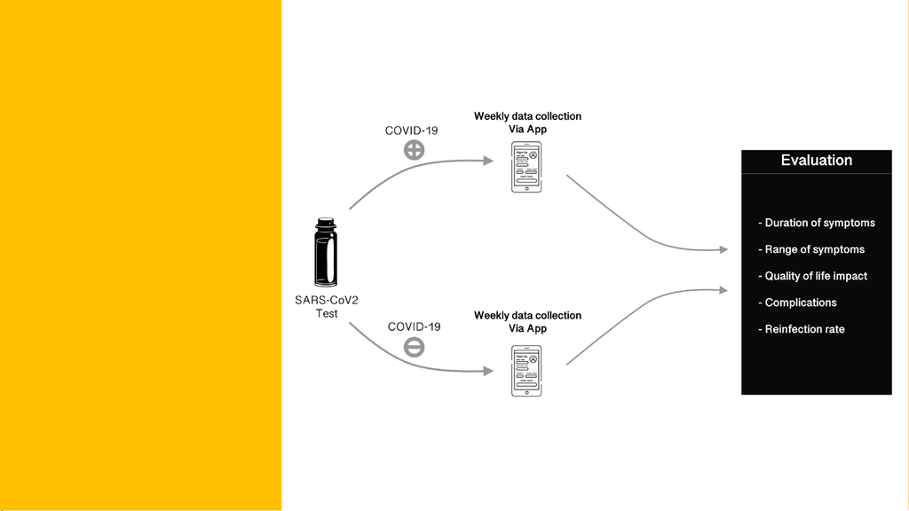

Prospective,

cohort study

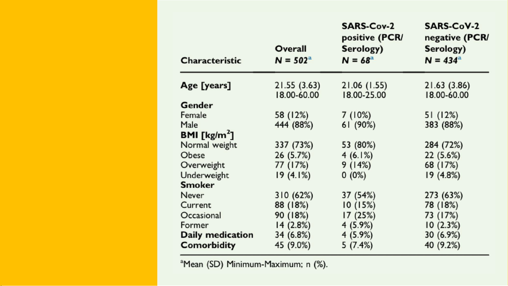

Socio-

demographic

characteristics

and health

determinants

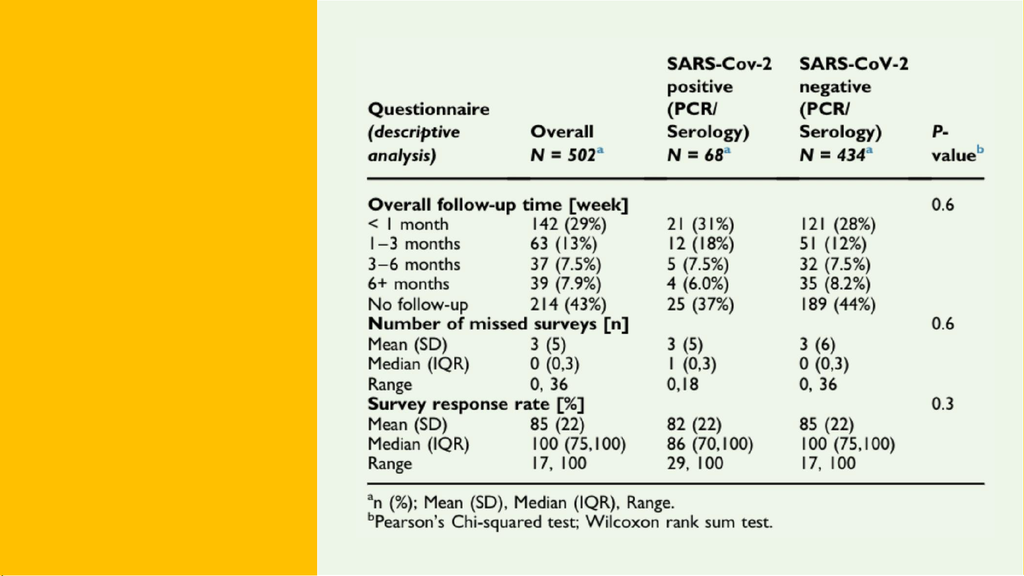

Follow-up

time and

participation

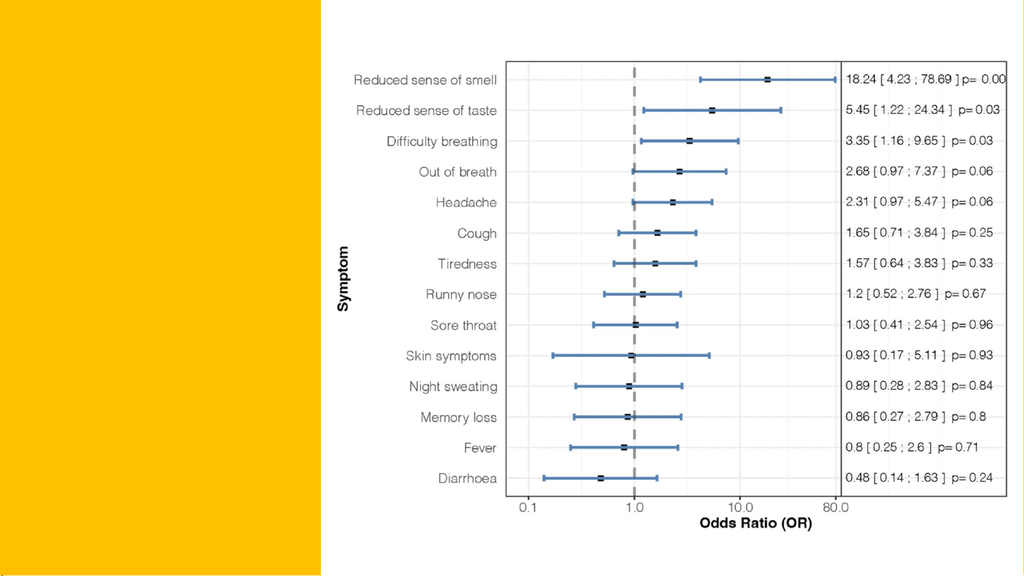

Odds ratio of

symptom

occurrence

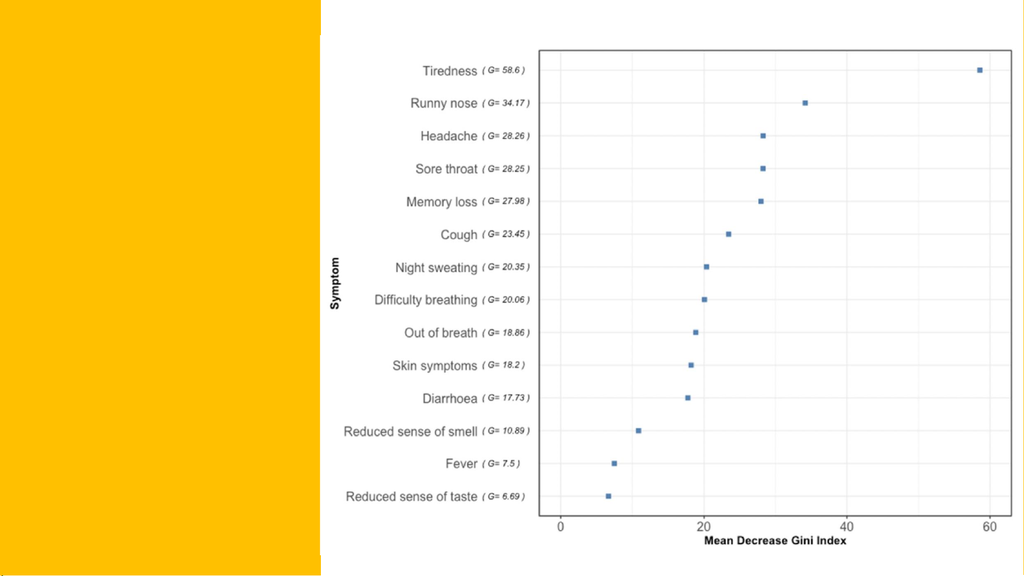

Impact of

symptoms on

daily activities

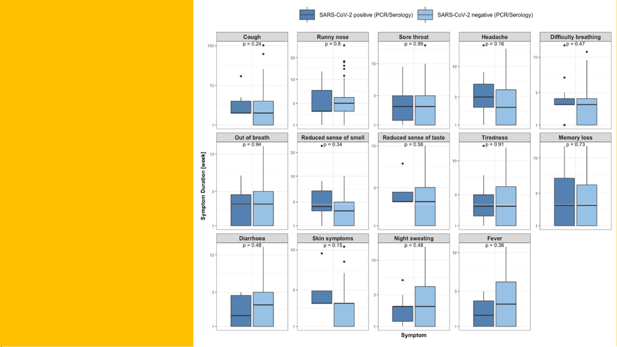

Time in weeks

to resolution of

symptoms

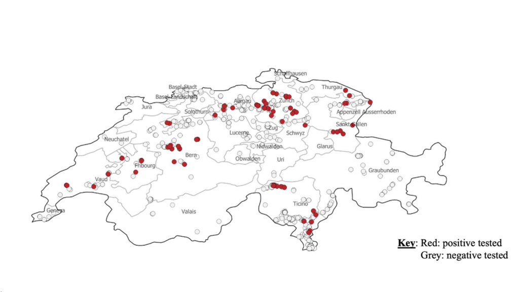

Geolocation of ITITP participants

Strength

•Strong and collaborative response to the call for participants

•Study population was homogenous, young and familiar with

smartphone and app technology

Limitations

•Retention and the enthusiasm declined over the year of

follow-up

•Gender imbalance

Take home-message

•Feasible to remotely monitor symptoms in persons infected

with SARS-CoV-2

•Those who tested positive for SARS-CoV-2 reported

significantly more symptoms that are typical of COVID-19

•Tiredness was the single symptom that was rated as having

a major impact on daily activities